# Joe Biden Twitter Analysis

```r
get_nrc_sentiment('delay')
```

```
##   anger anticipation disgust fear joy sadness surprise trust negative positive
## 1     1            0       1    1   0       1        0     0        1        0
```

Duygu Analizi BarPlot

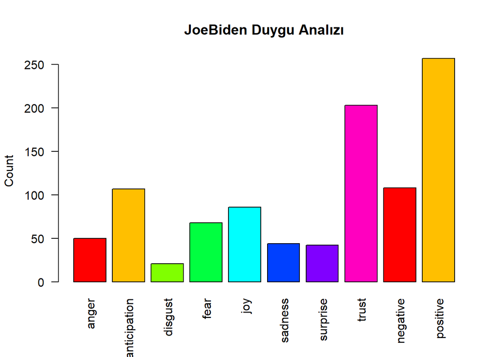

```r
barplot(colSums(s),
        las = 2,
        col = rainbow(8),
        ylab = 'Count',
        main = 'JoeBiden Duygu Analızı')
```

Daha sonra, metin sutununu joeBiden_Slim$text yukarda olusturdugumuz veri cercevesinden cikariyoruz:

```r
tweet_text <- joeBiden_Slim$text
head(tweet_text)
```

```
## [1] "Now the real work begins, folks. Follow along at @POTUS as we build back better. https://t.co/fHViqSqwp2"
## [2] "I love you, Jilly, and I couldn’t be more grateful to have you with me on the journey ahead. https://t.co/V4GUXAKSKg"
## [3] "Today, we begin anew. Tune in for #Inauguration2021. https://t.co/HxfU8q5riA"
## [4] "It’s a new day in America."
## [5] "Tonight, in Washington, D.C. and across the nation, we came together to honor the over 400,000 Americans we’ve lost… https://t.co/q3gB1RJjvv"
## [6] "We don’t have a second to waste when it comes to tackling the crises we face as a nation. That’s why after being sw… https://t.co/eza8IKs9Pf"
```

Ardindan Her Tweetin NRC duyarlilik puanlarini cikariyoruz

```r
nrc_data <- get_nrc_sentiment(tweet_text)
```

Duygu Analizine Gecebiliriz

Kizgin Tweetler

```r
angry_items <- which(nrc_data$anger >= 3)
tweet_text[angry_items] %>% head()
```

```
## [1] "Dr. Martin Luther King, Jr.’s words remind us that darkness cannot drive out darkness and hate cannot drive out hat… https://t.co/m3iRNj9Bzt"
## [2] "Today marks five years since the horrific ISIS terrorist attacks in Paris — an assault not just on the people of Fr… https://t.co/JY8DVIxHah"
```

Beklenti Tweetleri

```r
anticipation_items <- which(nrc_data$anticipation >= 3)
tweet_text[anticipation_items] %>% head()
```

```
## [1] "Service is a fitting way to start to heal, unite, and rebuild this country we love.\n\nI hope you’ll join us in honor… https://t.co/vL0SFZQdOF"
## [2] "It’s long past time to raise the minimum wage, so hardworking people earn at least $15 an hour. \n \nI hope that Demo… https://t.co/GjNx8dwly7"
## [3] "It’s long past time we pay teachers what they deserve.  \n\nThe work they do is of extreme national importance — and… https://t.co/PFOjoLqCPD"
## [4] "Georgia — Your vote has the power to change the future of this country. Don’t wait to use it. Make your plan to vot… https://t.co/Yj3MKVEZ7F"
## [5] "This team of world-class medical experts and public servants will be ready on day one to implement a full governmen… https://t.co/pxcGpzjdYA"
## [6] "With less than 50 days until Inauguration Day, now is the perfect time to stock up on gear to celebrate. Head to… https://t.co/hXgqFKEsq6"
```

Igrenc Tweetler

```r
disgust_items <- which(nrc_data$disgust >= 3)
tweet_text[disgust_items] %>% head()
```

```
## character(0)
```

Korku Tweetleri

```r
fear_items <- which(nrc_data$fear >= 3)
tweet_text[fear_items] %>% head()
```

```
## [1] "When it comes to the existential threat of climate change, we have no time to lose. This team will be ready on day… https://t.co/wGqdujmL69"
## [2] "We need to meet the threat of climate change with the urgency it demands — and seize the opportunity to build back… https://t.co/YZTcmZJy4g"
## [3] "Today marks five years since the horrific ISIS terrorist attacks in Paris — an assault not just on the people of Fr… https://t.co/JY8DVIxHah"
## [4] "The challenge before us right now is still immense and growing, and so is the need for bold action to fight this pandemic."
```

Sevinc Tweetleri

```r
joy_items <- which(nrc_data$joy >= 3)
tweet_text[joy_items] %>% head()
```

```
## [1] "Service is a fitting way to start to heal, unite, and rebuild this country we love.\n\nI hope you’ll join us in honor… https://t.co/vL0SFZQdOF"
## [2] "Jill and I send our heartfelt wishes to everyone celebrating Kwanzaa. We hope these days of reflection on the seven… https://t.co/lkoDY5be3C"
```

Uzgun Tweetler

```r
sadness_items <- which(nrc_data$sadness >= 3)
tweet_text[sadness_items] %>% head()
```

```
## character(0)
```

Supriz Tweetler

```r
surprise_items <- which(nrc_data$surprise >= 3)
tweet_text[surprise_items] %>% head()
```

```
## character(0)
```

Guven Tweetleri

```r
trust_items <- which(nrc_data$trust >= 3)
tweet_text[trust_items] %>% head()
```

```
## [1] "Service is a fitting way to start to heal, unite, and rebuild this country we love.\n\nI hope you’ll join us in honor… https://t.co/vL0SFZQdOF"
## [2] "Today, in a bipartisan vote, the House voted to impeach and hold President Trump accountable. Now, the process cont… https://t.co/BReZ8t0gO0"
## [3] "Ambassador Samantha Power is a world-renowned voice of conscience and moral clarity—challenging and rallying the in… https://t.co/OyZ8P13yrB"
## [4] "Our president is not above the law. \n\nJustice serves the people — it doesn’t protect the powerful."
## [5] "We need to restore the honor, the integrity, and the independence of the Department of Justice in this nation — and… https://t.co/S0uSg2zMkk"
## [6] "I’m proud to nominate Judge Merrick Garland for Attorney General of the United States. https://t.co/xBR5PAN2wH"
```

## Genel Duygular

Son olarak, tum tweetlerdeki her bir duygunun yuzdesini cizerek Joe Biden’ in tweetlerindeki genel duygulari anlayalim

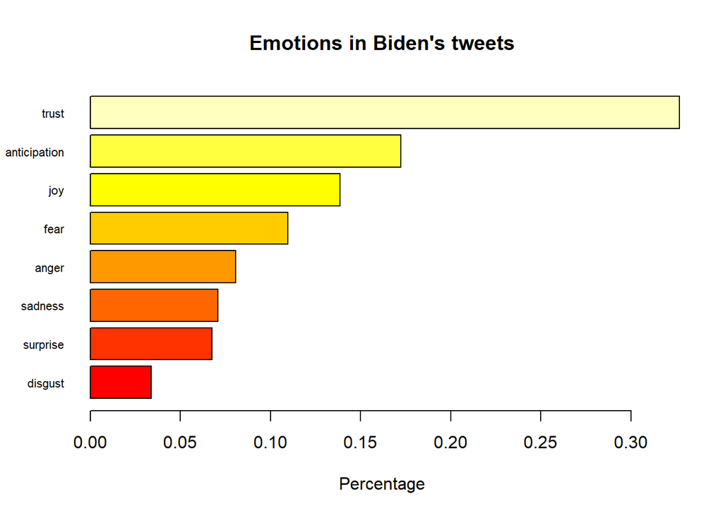

```r
barplot(
  sort(colSums(prop.table(nrc_data[, 1:8]))),
  horiz = TRUE,
  cex.names = 0.7,
  las = 1,
  col=heat.colors(8),
  main = "Emotions in Biden's tweets", xlab="Percentage"
)
```

## Tweet Temizleme

```r
library(tidytext)

reg <- "([^A-Za-z\\d#@']|'(?![A-Za-z\\d#@]))"
tweet_words <- tweets %>%
  filter(!str_detect(text, '^"')) %>%
  mutate(text = str_replace_all(text, "https://t.co/[A-Za-z\\d]+|&amp;", "")) %>%
  unnest_tokens(word, text, token = "regex", pattern = reg) %>%
  filter(!word %in% stop_words$word,
         str_detect(word, "[a-z]"))

head(tweet_words)
```

```
##   favorited favoriteCount replyToSN             created truncated replyToSID
## 1     FALSE        900028      <NA> 2021-01-20 17:55:22     FALSE       <NA>
## 2     FALSE        900028      <NA> 2021-01-20 17:55:22     FALSE       <NA>
## 3     FALSE        900028      <NA> 2021-01-20 17:55:22     FALSE       <NA>
## 4     FALSE        900028      <NA> 2021-01-20 17:55:22     FALSE       <NA>
## 5     FALSE        900028      <NA> 2021-01-20 17:55:22     FALSE       <NA>
## 6     FALSE        900028      <NA> 2021-01-20 17:55:22     FALSE       <NA>
##                    id replyToUID
## 1 1351951465674276869       <NA>
## 2 1351951465674276869       <NA>
## 3 1351951465674276869       <NA>
## 4 1351951465674276869       <NA>
## 5 1351951465674276869       <NA>
## 6 1351951465674276869       <NA>
##                                                                         statusSource
## 1 <a href="http://twitter.com/download/iphone" rel="nofollow">Twitter for iPhone</a>
## 2 <a href="http://twitter.com/download/iphone" rel="nofollow">Twitter for iPhone</a>
## 3 <a href="http://twitter.com/download/iphone" rel="nofollow">Twitter for iPhone</a>
## 4 <a href="http://twitter.com/download/iphone" rel="nofollow">Twitter for iPhone</a>
## 5 <a href="http://twitter.com/download/iphone" rel="nofollow">Twitter for iPhone</a>
## 6 <a href="http://twitter.com/download/iphone" rel="nofollow">Twitter for iPhone</a>
##   screenName retweetCount isRetweet retweeted longitude latitude   word
## 1   JoeBiden        63766     FALSE     FALSE        NA       NA   real
## 2   JoeBiden        63766     FALSE     FALSE        NA       NA begins
## 3   JoeBiden        63766     FALSE     FALSE        NA       NA  folks
## 4   JoeBiden        63766     FALSE     FALSE        NA       NA follow
## 5   JoeBiden        63766     FALSE     FALSE        NA       NA @potus
## 6   JoeBiden        63766     FALSE     FALSE        NA       NA  build
```

```r
##corupus temızleme
mycorpus <- VCorpus(VectorSource(tweets$text))

removeURL <- function(x) gsub("http[[:alnum:]]*","",x)
removeNumPunct <- function(x) gsub("[^[:alpha:][:space:]]*","",x)
```

Istenmeyen Kelimeleri Cikaralim

```r
new_stop <- c(stopwords("en"),"rt","one","news")
```

```r
clean_tweets <- tm_map(mycorpus,PlainTextDocument)
clean_tweets <- tm_map(clean_tweets,content_transformer(removeURL))
clean_tweets <- tm_map(clean_tweets, stripWhitespace)
clean_tweets <- tm_map(clean_tweets, content_transformer(tolower))
clean_tweets <- tm_map(clean_tweets, removeWords, new_stop)
clean_tweets <- tm_map(clean_tweets,content_transformer(removeNumPunct))
clean_tweets <- tm_map(clean_tweets, removePunctuation)
```

Verideki 25. Tweeti Alalim ve Temizlik Gerceklesmis mi Kontrol Edelim

```r
tweets$text[25] ## Temızlık Oncesı
```

```
## [1] "My administration will move Heaven and Earth to:\n\n- Allow more people to get vaccinated\n- Create more places for th… https://t.co/yLoRNU2MKF"
```

```r
clean_tweets[[25]][1] ## Temızlık Sonrası
```

```
## $content
## [1] " administration will move heaven  earth   allow  people  get vaccinated  create  places  th tcoylornumkf"
```

```r
tweets_tdm <- TermDocumentMatrix(clean_tweets)
tweets_tdm
```

```
## <<TermDocumentMatrix (terms: 1012, documents: 176)>>
## Non-/sparse entries: 1846/176266
## Sparsity           : 99%
## Maximal term length: 18
## Weighting          : term frequency (tf)
```

```r
tweets_m <- as.matrix(tweets_tdm)
dim(tweets_m)
```

```
## [1] 1012  176
```

## Kullanilan Kelime Coklugu ile WordCloud Olusturma

```r
##sık kullanılan kelımelerr
term_frequency <- rowSums(tweets_m)
term_frequency <- sort(term_frequency,decreasing = TRUE)
term_frequency[1:10]
```

```
##           will           need          covid          today            day
##             30             19             17             17             16
##           work        america         people           tune administration
##             16             15             14             12             11
```

En cok kullanilan kelimelerin BarPlotu

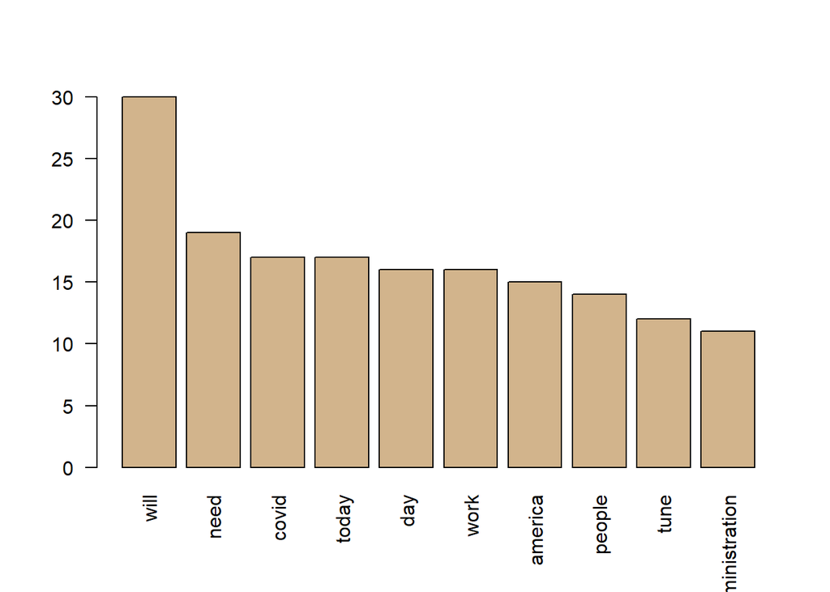

```r
barplot(term_frequency[1:10],col ="tan", las = 2)
```

Kullanilan Kelimelerin Sklik Dagilimi

```
## geom_path: Each group consists of only one observation. Do you need to adjust
## the group aesthetic?
```

[figure not shown]

```r
##20 ve üzerı

term_frequency <- subset(term_frequency,term_frequency >= 20)
term_freq_df <- data.frame(term = names(term_frequency),freq = term_frequency)
ggplot(term_freq_df,aes(x=term,y=freq)) +
  geom_line(aes(group=1),colour="blue") +
  geom_point(size = 3,colour = "pink2") +
  xlab("Kelime") + ylab("Sıklık") + coord_flip()
```

WordCloud Olusturma

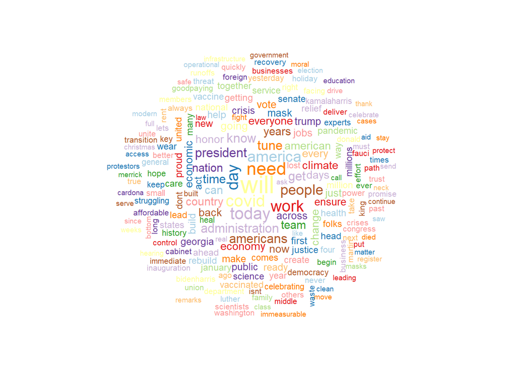

```r
wordcloud(clean_tweets,min.freq = 2,scale = c(2,0.5) , colors =brewer.pal(12,"Paired"),
          random.color = TRUE, random.order = FALSE, max.words = 200)
```

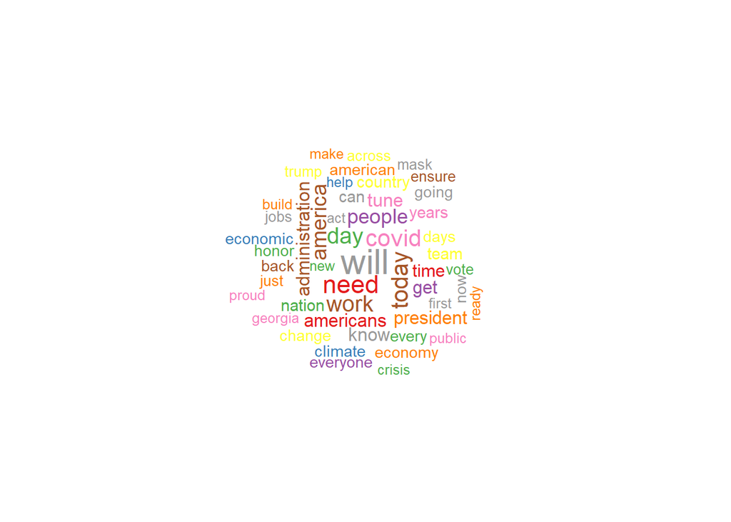

```r
wordcloud(clean_tweets,min.freq = 2,scale = c(2,0.5) , colors =brewer.pal(9,"Set1"),
          random.color = TRUE, random.order = FALSE, max.words = 50)
```

[figure not shown]

```r
word_freqs <- data.frame(term_frequency,term =names(term_frequency),num = term_frequency)
wordcloud(word_freqs$term,word_freqs$num,max.words = 100, colors = brewer.pal(11,"RdYlGn"),random.color = TRUE)
```

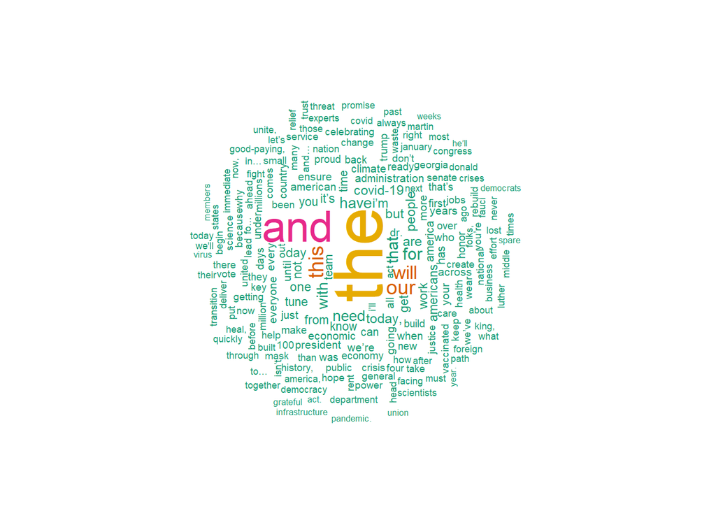

```r
dtm = DocumentTermMatrix(mycorpus)
dtm = removeSparseTerms(dtm, 0.999)
dataset = as.matrix(dtm)
v = sort(colSums(dataset),decreasing=TRUE)
myNames = names(v)
d = data.frame(word=myNames,freq=v)

wordcloud(d$word,d$freq,min.freq = 1,max.words=200,random.order=FALSE, rot.per=0.35,colors=brewer.pal(6, "Dark2"))
```